# Los Grupos cristalográficos.

Cargamos los módulos necesarios para la creación de nuestras funciones.

```python
from PIL import Image
```

```python
from sympy import *
```

```python
from numpy import *
```

```python
from math import *
```

Cargamos una imagen:

```python
imagen = Image.open('salamanquesa.jpeg')
```

[figure not shown]

```python
imagen
```

La primera función que creamos "mini" transforma la imagen en una miniatura para poder trabajarla en mosaicos. Ajustamos los pixeles de la foto a 120x120.

```python
def mini(imag):
    imagaux=imag
    miniatura = (120, 120)
    imagaux.thumbnail(miniatura)
    return(imagaux)
```

```python
au=mini(imagen)
```

[figure not shown]

```python
au
```

Creamos funciones para ver como actuan los principales grupos ornamentales. Simetrias horizontales, verticales, con deslizamiento y rotaciones. $\mathbb Z$

```python
def SimVertical(imag):
    mp=imag.load()
    imagaux=Image.new("RGB",(imag.size[0]*2,imag.size[1]),"white")
    mpaux=imagaux.load()
    for i in range(imag.size[0]):
        for j in range(imag.size[1]):
            mpaux[i,j]=mp[i,j]
    for i in range(imag.size[0]):
        for j in range(imag.size[1]):
            mpaux[imag.size[0]+i,j]=mpaux[imag.size[0]-i-1,j]
    return(imagaux)
```

[figure not shown]

```python
SimVertical(au)
```

```python
def SimHorizontal(imag):
    mp=imag.load()
    imagaux=Image.new("RGB",(imag.size[0],imag.size[1]*2),"white")
    mpaux=imagaux.load()
    for i in range(imag.size[0]):
        for j in range(imag.size[1]):
            mpaux[i,j]=mp[i,j]
    for i in range(imag.size[0]):
        for j in range(imag.size[1]):
            mpaux[i,imag.size[1]+j]=mpaux[i,imag.size[1]-j-1]
    return(imagaux)
```

[figure not shown]

```python
SimHorizontal(au)
```

```python
def SimHoDesliz(imag):
    mp=imag.load()
    imagaux=Image.new("RGB",(imag.size[0]*2,imag.size[1]*2),"white")
    mpaux=imagaux.load()
    imsim=Image.new("RGB",(imag.size[0],imag.size[1]),"white")
    mpsim=imsim.load()
    for i in range(imag.size[0]):
        for j in range(imag.size[1]):
            mpsim[i,j]=mp[i,imag.size[1]-j-1]
    imagaux.paste(imag, (0,0))
    imagaux.paste(imag, (0,imag.size[1]))
    imagaux.paste(imsim, (imag.size[0],0))
    imagaux.paste(imsim, (imag.size[0],imag.size[1]))
    return(imagaux)
```

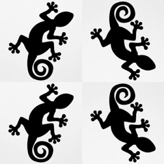

```python
SimHoDesliz(au)
```

```python
def SimVeDesliz(imag):
    mp=imag.load()
    imagaux=Image.new("RGB",(imag.size[0]*2,imag.size[1]*2),"white")
    mpaux=imagaux.load()
    imsim=Image.new("RGB",(imag.size[0],imag.size[1]),"white")
    mpsim=imsim.load()
    for i in range(imag.size[0]):
        for j in range(imag.size[1]):
            mpsim[i,j]=mp[imag.size[0]-i-1,j]
    imagaux.paste(imag, (0,0))
    imagaux.paste(imsim, (0,imag.size[1]))
    imagaux.paste(imag, (imag.size[0],0))
    imagaux.paste(imsim, (imag.size[0],imag.size[1]))
    return(imagaux)
```

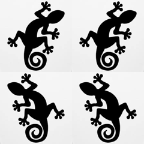

```python
SimVeDesliz(au)
```

Para las rotaciones usaremos la función rotate predefinida en el modulo PIL.

[figure not shown]

```python
au.rotate(90)
```

Creamos ahora funciones que den como salida la imagen simetrizada:

```python
def SimV(imag):
    mp=imag.load()
    imagaux=Image.new("RGB",(imag.size[0],imag.size[1]),"white")
    mpaux=imagaux.load()
    for i in range(imag.size[0]):
        for j in range(imag.size[1]):
            mpaux[i,j]=mp[imag.size[0]-i-1,j]

    return(imagaux)
```

[figure not shown]

```python
SimV(au)
```

```python
def SimH(imag):
    mp=imag.load()
    imagaux=Image.new("RGB",(imag.size[0],imag.size[1]),"white")
    mpaux=imagaux.load()
    for i in range(imag.size[0]):
        for j in range(imag.size[1]):
            mpaux[i,j]=mp[i,imag.size[1]-j-1]
    return(imagaux)
```

[figure not shown]

```python
SimH(au)
```

Una vez tenemos los Grupos ornamentales, procedemos a crear funciones que como entrada tienen el rango y la imagen y como salida de el grupo actuando sobre la imagen

Antes de cada funcion cargaremos una imagen esquematica, con el fin de entender mejor el comportamiento del mosaico, de como se comporta la región fundamental. Donde existen traslaciones, simetrias y rotaciones.

# P1

```python
ip1 = Image.open('p1.jpg')
```

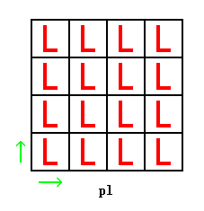

```python
ip1
```

```python
def p1(imag,rang):
    im1=Image.new("RGB",(imag.size[0]*rang,imag.size[1]*rang),"white")
    for i in range(0,rang):
        for j in range(0,rang):
            im1.paste(imag, (i*imag.size[0],j*imag.size[1]))
    return(im1)
```

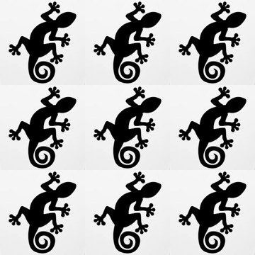

```python
p1(au,3)
```

# P2

```python
ip2 = Image.open('p2.jpg')
```

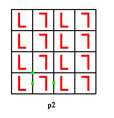

```python
ip2
```

```python
def p2(imag,rang):
    im1=Image.new("RGB",(imag.size[0]*rang*2,imag.size[1]*rang*2),"white")
    im2=Image.new("RGB",(imag.size[0],imag.size[1]*2),"white")
    rot = imag.rotate(180)#, expand=1)
    im2.paste(imag, (0,0))
    im2.paste(rot, (0,imag.size[1]))
    for i in range(0,rang*2):
        for j in range(0,rang):
            im1.paste(im2, (i*imag.size[0],j*2*imag.size[1]))
    return(im1)
```

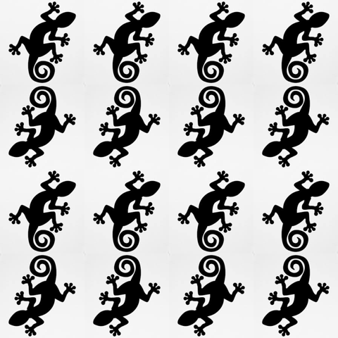

```python
p2(au,2)
```

# Pm

```python
ipm = Image.open('pm.jpg')
```

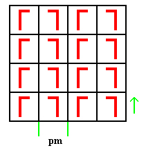

```python
ipm
```

```python
def pm(imag,rang):
    im1=Image.new("RGB",(imag.size[0]*rang*2,imag.size[1]*rang*2),"white")
    im2=SimVertical(imag)
    for i in range(0,rang):
        for j in range(0,rang*2):
            im1.paste(im2, (i*2*imag.size[0],j*imag.size[1]))
    return(im1)
```

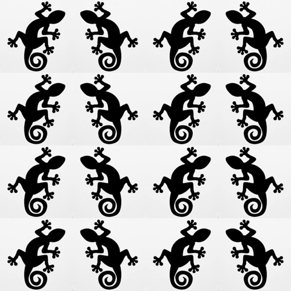

```python
pm(au,2)
```

# Pg

```python
ipg = Image.open('pg.jpg')
```

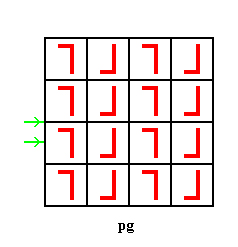

```python
ipg
```

```python
def pg(imag,rang):
    im1=Image.new("RGB",(imag.size[0]*rang*2,imag.size[1]*rang*2),"white")
    im2=SimHoDesliz(imag)
    for i in range(0,rang*2):
        for j in range(0,rang*2):
            im1.paste(im2, (i*2*imag.size[0],j*2*imag.size[1]))
    return(im1)
```

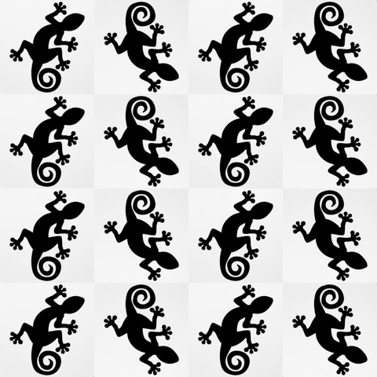

```python
pg(au,2)
```

# Pmm

```python
ipmm = Image.open('pmm.jpg')
```

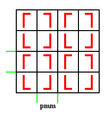

```python
ipmm
```

```python
def pmm(imag,rang):
    a3=imag
    for i in range(rang):
        a1=SimVertical(a3)
        a2=SimHorizontal(a1)
        a3=a2

        i=i+1
    return(a3)
```

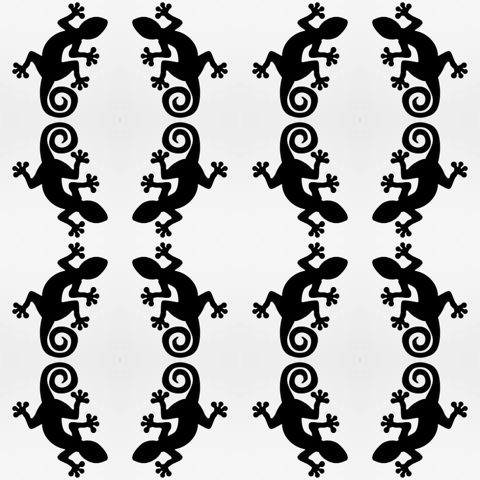

```python
pmm(au,2)
```